# Tutorial de Dashboard

.

# Tutorial de Dashboard

#### Kaíque Ferreira Henrique de Souza

#### **kaiquefhds@gmail.com**

##### 31 de Março de 2020

.

# Introdução

Nesse tutorial eu vou te mostrar passo a passo como fazer cada parte de um Shiny Dashboard e de um Flexdashboard utilizando exemplos é inúmeras outras ferramentas para você ao final conseguir desenvolver o seu Dashboard

.

.

# 1. Shiny Dashboard ou Flexdashboard?

## 1.1 Exemplos de Shiny Dashboard

- https://adminlte.io/themes/AdminLTE/index2.html

[figure not shown]

Outros exemplos de Shiny Dashboard:

- https://rinterface.com/shiny/shinydashboardPlus/
- https://emprego-estatistico.shinyapps.io/VagaEstat/
- http://shinyapps.dreamrs.fr/shinyWidgets/

.

## 1.2 Exemplos de Flexdashboards

- https://beta.rstudioconnect.com/jjallaire/htmlwidgets-showcase-storyboard/htmlwidgets-showcase-storyboard.html

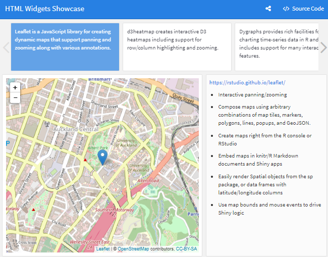

Galeria com FlexDashboards:

- https://rmarkdown.rstudio.com/flexdashboard/examples.html

.

# 2. Shiny Dashboard

Com o script abaixo conseguimos gerar um Shiny Dashboard vazio

```r
library(shiny)
library(shinydashboard)

Header  = dashboardHeader()
Sidebar = dashboardSidebar()
Body    = dashboardBody()

UI = dashboardPage(Header, Sidebar, Body)

Server = function(input, output) { }

shinyApp(UI, Server)
```

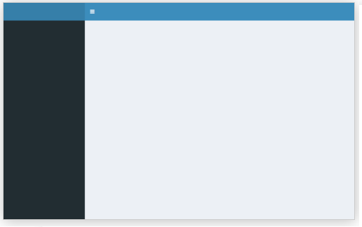

Assim que executar o código acima terá um Shiny Dashboard em branco onde poderá incrementar inúmeras ferramentas(mostrarei algumas em seguida) para enfim chegar a obter o seu objetivo final de Shiny Dashboard, lembre-se que é possível realizar as mais diversas personalizações em seu Shiny Dashboard. Para isso, conheceremos as principais estruturas do Shiny Dashboard.

## 2.1 Shiny Dashboard Final

- Acesse o Shiny Dashboard pelo [LINK](https://kaiquefhds.shinyapps.io/completo/)

[figure not shown]

.

## 2.2 Principais Pacotes

### 2.2.1 Instalando pacotes

```r
install.packages("shiny")
install.packages("shinydashboard")
```

.

### 2.2.2 Principais Funções

- dashboardSidebar()
- dashboardBody()
- dashboardHeader()
- dashboardPage()
- shinyApp()

.

### 2.2.3 Detalhes sobre os pacotes

Mais detalhes sobre os pacotes podem ser encontrados em suas documentações:

- https://www.rdocumentation.org/packages/shinydashboard/versions/0.7.1
- https://www.rdocumentation.org/packages/shiny/versions/1.4.0

.

## 2.3 Pacotes Extras

### 2.3.1 Instalando pacotes

```r
  library(shinyWidgets)
  library(shinydashboardPlus)
```

.

### 2.3.2 Principais Funções

- shinyWidgetsGallery()
- shinydashboardPlusGallery()

Essas funções abrem Shiny Dashboards inestimáveis para o desenvolvimento do seu Shiny Dashboard

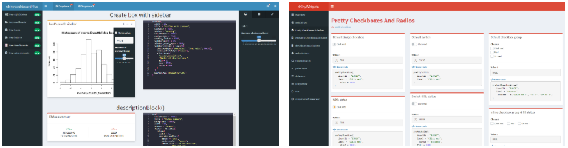

Caso não consiga usar as funções entre pelo site

- https://rinterface.com/shiny/shinydashboardPlus/
- http://shinyapps.dreamrs.fr/shinyWidgets/

.

### 2.3.3 Detalhes sobre os pacotes

Mais detalhes sobre os pacotes podem ser encontrados em suas documentações:

- https://www.rdocumentation.org/packages/shinyWidgets/versions/0.4.9
- https://www.rdocumentation.org/packages/shinydashboardPlus/versions/0.7.0

.

## 2.4 Estruturas Principais

A estrutura de um Shiny Dashboard é bem sistematizada, para realizar alterações no Dashboarda é necessário além de um código correto que implementara a alteração desejada você precisara escolher em qual função e qual posição colocará o código novo, veja o seguinte código:

```r
# Input de interação com o usuário

sliderInput(inputId = "n", # ID do menu de seleção
            label = "Nº de Observações", # Nome que o usuário visualizará
            1, 1000, 100) # Primeiro valor, último valor, valor selecionado inicialmente
```

Observe o que acontece se adicionarmos ele na função dashboardSidebar()

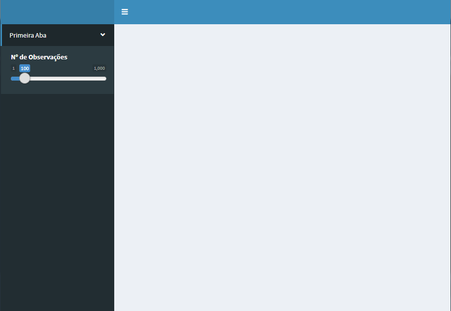

```r
Sidebar = dashboardSidebar(
  sidebarMenu(

    menuItem("Primeira Aba",          # Nome que o usuário visualizará
             tabName = "PrimeiraAba",  # ID da aba para usar posteriormente

             # Input de interação com o usuário
             sliderInput(inputId = "n", # ID do menu de seleção
                         label = "Nº de Observações", # Nome que o usuário visualizará
                         1, 1000, 100) # Primeiro valor, último valor, valor seleciondo inicialmente

             )  # Fim da função menuItem
  ) # Fim da função sidebarMenu
) # Fim da função dashboardSidebar
```

Esse seria o resultado se estivesse dentro da função dashboardBody()

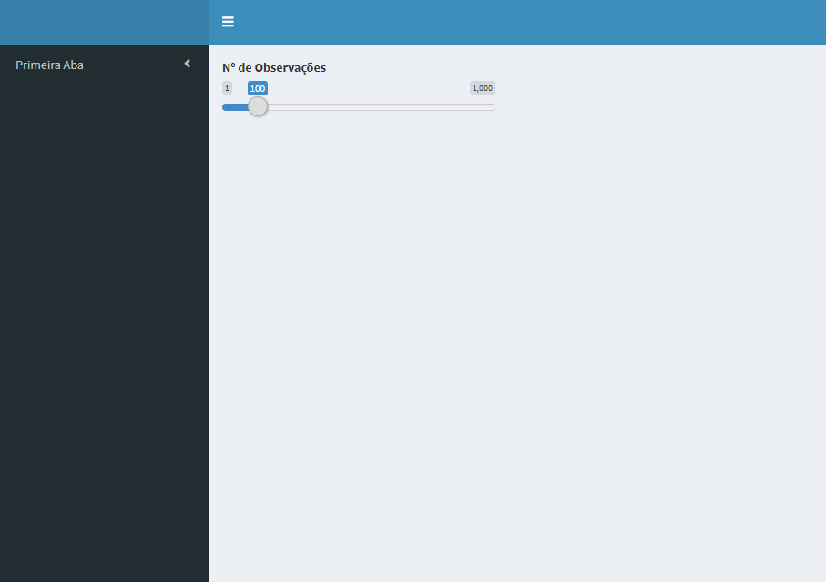

```r
Body = dashboardBody({

  sliderInput(inputId = "n", # ID do menu de seleção
              label = "Nº de Observações", # Nome que o usuário visualizará
              1, 1000, 100) # Primeiro valor, último valor, valor selecionado inicialmente

}) # Fim da função dashboardBody
```

Para compreendermos um pouco mais sobre essas opções, vejamos agora um pouco melhor sobre algumas funções principais que compõem a estrutura de um Shiny Dashboard

.

### 2.4.1 Função: dashboardHeader()

A documentação da função pode ser encontrada no [LINK](https://www.rdocumentation.org/packages/shinydashboard/versions/0.7.1/topics/dashboardHeader), e as alterações dentro da função dashboardHeader afetam a parte destacada na figura abaixo

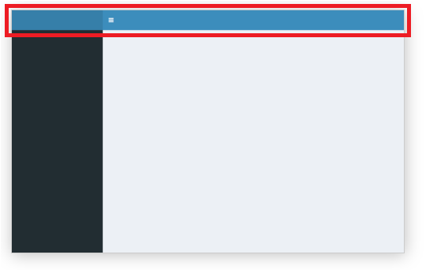

Construiremos passo a passo até chegarmos nesse objetivo final

- https://kaiquefhds.shinyapps.io/header/

[figure not shown]

Utilize o Código Completo Header e retire todo o Header para construirmos gradativamente, primeiro vamos adicionar o RightSidebar que é o menu a direita, para isso precisaremos fazer duas trocas, elas são indispensáveis:

- Troque a função *dashboardHeader()* pela função *dashboardHeaderPlus()*
- Troque a função *dashboardPage()* pela função *dashboardPagePlus()*

Às duas novas funções pertencem ao pacote *shinydashboardPlus* que também sera necessário carregar no início do seu código e esse será o resultado

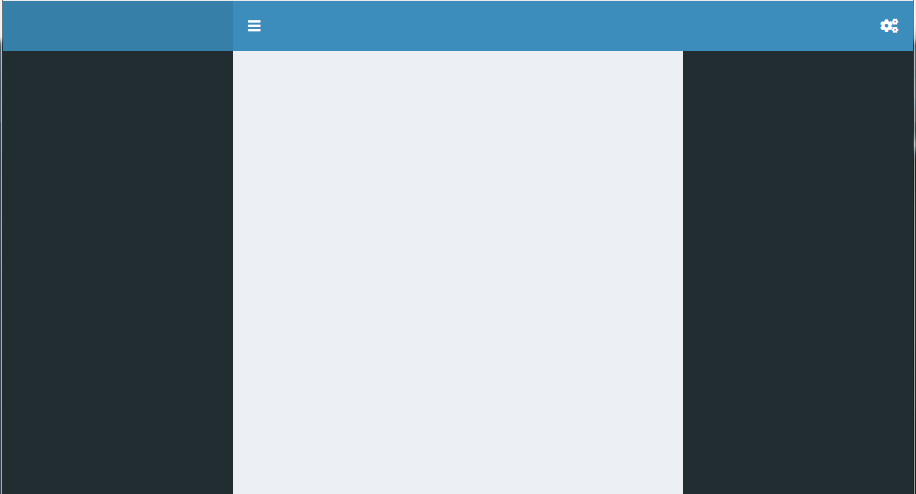

```r
library(shinydashboardPlus)

Header = dashboardHeaderPlus(

  enable_rightsidebar = TRUE,  # Ativando menu a direita
  rightSidebarIcon = "gears"  # Icone do menu a direita

) # Fim da função Header
```

Na parte 2.4.3 veremos como adicionar algo no RightSidebar, a aba de informações pode ser inserida com a função *dropdownMenu*. Não esqueça de adicionar uma vírgula separando os componentes do Header

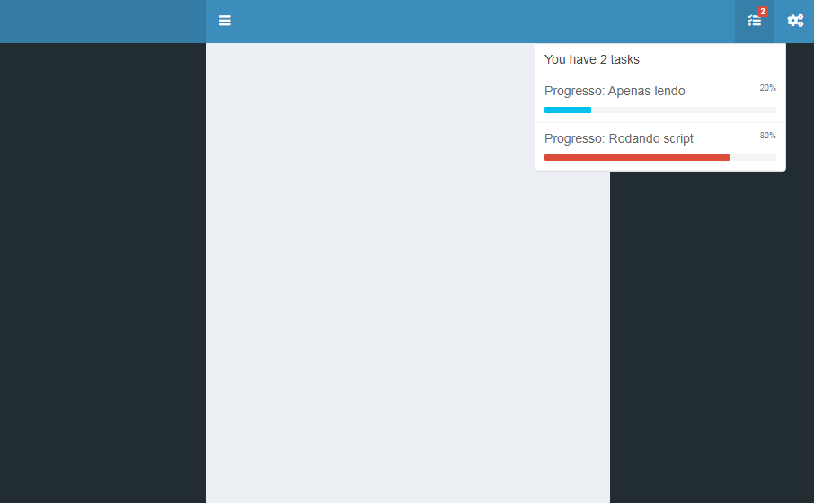

```r
Header = dashboardHeaderPlus(

  enable_rightsidebar = TRUE,  # Ativando menu a direita
  rightSidebarIcon = "gears",  # Icone do menu a direita

    # Aba de informações a direita
  dropdownMenu(
    type = "tasks",
    badgeStatus = "danger",
    taskItem(value = 20, color = "aqua", "Progresso: Apenas lendo"),
    taskItem(value = 80, color = "red", "Progresso: Rodando script")  )
) # Fim da função Header
```

Mais detalhes podem ser encontrados no [LINK](https://www.rdocumentation.org/packages/shinydashboard/versions/0.7.1/topics/dropdownMenu).

Para adicionar o menu a esquerda utilizaremos a função *dropdownBlock* colocando ela dentro da função *tagList* da seguinte maneira

```r
Header = dashboardHeaderPlus(

  enable_rightsidebar = TRUE,  # Ativando menu a direita
  rightSidebarIcon = "gears",  # Icone do menu a direita

  # Aba de informações a direita
  dropdownMenu(
    type = "tasks",
    badgeStatus = "danger",
    taskItem(value = 20, color = "aqua", "Progresso: Apenas lendo"),
    taskItem(value = 80, color = "red", "Progresso: Rodando script")  ),

  # Função para adicionar itens a esquerda do Header
  left_menu = tagList(

    # Menu a esquerda
    dropdownBlock(
      id = "dropdownE",
      title = "Dropdown E",  # Nome visto pelo usuário
      icon = "sliders"  # Icone ao lado do nome
    ) # Fim do dropdownBlock
   ) # Fim da função tagList que leva o dropdonw para a esqueda do header
  ) # Fim da função Header
```

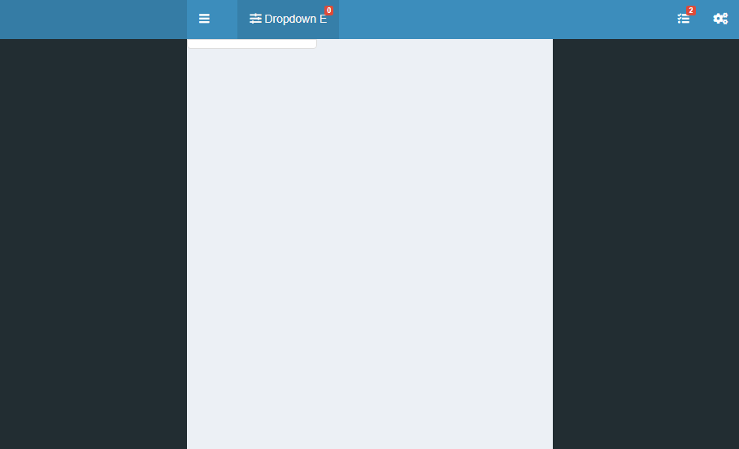

Para adicionar a ferramenta de seleção dentro do menu basta adicionar uma vírgula após o último argumento dentro da função dropdownBlock junto com o código abaixo

```r
# Ferramenta de rolagem para escolha de um número pelo usuário
      sliderInput(
        inputId = "n",  # ID para obter o output escolhido pelo usuário
        label = "Nº de observações",  # Título da bara de rolagem
        min = 10, max = 1000, value = 100 ) # Número mínimo, máximo e o número inicial
```

Lembre-se que existem inúmeros tipos de ferramentas como essa que podem ser adicionadas, estou usando apenas uma como exemplo, o resultado será esse

```r
Header = dashboardHeaderPlus(

  enable_rightsidebar = TRUE,  # Ativando menu a direita
  rightSidebarIcon = "gears",  # Icone do menu a direita

  # Aba de informações a direita
  dropdownMenu(
    type = "tasks",
    badgeStatus = "danger",
    taskItem(value = 20, color = "aqua", "Progresso: Apenas lendo"),
    taskItem(value = 80, color = "red", "Progresso: Rodando script")  ),

  # Função para adicionar itens a esquerda do Header
  left_menu = tagList(

    # Menu a esquerda
    dropdownBlock(
      id = "dropdownE",
      title = "Dropdown E",  # Nome visto pelo usuário
      icon = "sliders",  # Icone ao lado do nome

      # Ferramenta de rolagem para escolha de um número pelo usuário
      sliderInput(
        inputId = "n",  # ID para obter o output escolhido pelo usuário
        label = "Nº de observações",  # Título da bara de rolagem
        min = 10, max = 1000, value = 100 ) # Número mínimo, máximo e o número inicial
    ) # Fim do dropdownBlock
   ) # Fim da função tagList que leva o dropdonw para a esqueda do header
  ) # Fim da função Header
```

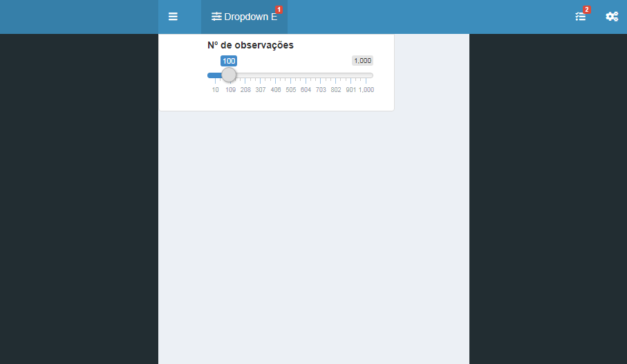

Para adicionar os botões das redes sociais usaremos a função socialButton dentro da função taglist, mais detalhes podem ser encontrados no [LINK](https://www.rdocumentation.org/packages/shinydashboardPlus/versions/0.7.0/topics/socialButton)

Esse é um exemplo de como configurar o botão do github

```r
# Butão para direcionar as redes sociais
socialButton(
      url = "https://github.com/Kaique-fhs", # Site que será encaminhado ao clicar no botão
      type = "github" ) # Redes sociais pre definidas
```

Adicionando dentro do Header com todas as outras redes sociais temos o seguinte resultado

[figure not shown]

```r
Header = dashboardHeaderPlus(

  enable_rightsidebar = TRUE,  # Ativando menu a direita
  rightSidebarIcon = "gears",  # Icone do menu a direita

  # Aba de informações a direita
  dropdownMenu(
    type = "tasks",
    badgeStatus = "danger",
    taskItem(value = 20, color = "aqua", "Progresso: Apenas lendo"),
    taskItem(value = 80, color = "red", "Progresso: Rodando script")  ),

  # Função para adicionar itens a esquerda do Header
  left_menu = tagList(

    # Menu a esquerda
    dropdownBlock(
      id = "dropdownE",
      title = "Dropdown E",  # Nome visto pelo usuário
      icon = "sliders",  # Icone ao lado do nome

      # Ferramenta de rolagem para escolha de um número pelo usuário
      sliderInput(
        inputId = "n",  # ID para obter o output escolhido pelo usuário
        label = "Nº de observações",  # Título da barra de rolagem
        min = 10, max = 1000, value = 100 ) # Número mínimo, máximo e o número inicial
    ), # Fim do dropdownBlock

    # Butão para direcionar as redes sociais
    socialButton(
      url = "https://github.com/Kaique-fhs", # Site que será encaminhado ao clicar no botão
      type = "github" ), # Redes sociais pre definidas
    socialButton(
      url = "https://www.linkedin.com/in/ka%C3%ADque-ferreira-883b32182/",
      type = "linkedin" ),
    socialButton(
      url = "https://www.instagram.com/kaique_fhds/?hl=pt-br",
      type = "dropbox" ),
    socialButton(
      url = "https://www.facebook.com/kaique.ferreira.79069",
      type = "facebook" )

  ) # Fim da função tagList que leva o dropdonw para a esquerda do header
) # Fim da função Header
```

Esse é o [LINK](https://github.com/lipis/bootstrap-social) onde se pode encontrar as variações de botões que a função *socialButton* consegue adicionar. E por último, adicionaremos o título utilizando o argumento *title* da função *dashboardHeaderPlus* da seguinte maneira

```r
  title = "Tutorial Shiny Dashboard",  # Frase acima do sidebar
  titleWidth = "270px", # Ajuste de espaço disponível para a frase
```

Percebam que foi preciso ajustar o espaço com o argumento *titleWidth*, neste caso aumentamos o espaço para 270px e assim alcançamos o nosso objetivo final

[figure not shown]

```r
Header = dashboardHeaderPlus(

  title = "Tutorial Shiny Dashboard",  # Frase acima do sidebar
  titleWidth = "270px", # Espaço disponível para a frase

  enable_rightsidebar = TRUE,  # Ativando menu a direita
  rightSidebarIcon = "gears",  # Icone do menu a direita

  # Função para adicionar itens a esquerda do Header
  left_menu = tagList(

    # Menu a esquerda
    dropdownBlock(
      id = "dropdownE",
      title = "Dropdown E",  # Nome visto pelo usuário
      icon = "sliders",  # Icone ao lado do nome

      # Ferramenta de rolagem para escolha de um número pelo usuário
      sliderInput(
        inputId = "n",  # ID para obter o output escolhido pelo usuário
        label = "Nº de observações",  # Título da bara de rolagem
        min = 10, max = 1000, value = 100 ) # Número mínimo, máximo e o número inicial
    ), # Fim do dropdownBlock

    # Butão para direcionar as redes sociais
    socialButton(
      url = "https://github.com/Kaique-fhs", # Site que será encaminhado ao clicar no botão
      type = "github" ), # Redes sociais pre definidas
    socialButton(
      url = "https://www.linkedin.com/in/ka%C3%ADque-ferreira-883b32182/",
      type = "linkedin" ),
    socialButton(
      url = "https://www.instagram.com/kaique_fhds/?hl=pt-br",
      type = "dropbox" ),
    socialButton(
      url = "https://www.facebook.com/kaique.ferreira.79069",
      type = "facebook" )

  ), # Fim da função tagList que leva o dropdonw para a esqueda do header

  # Menu a direita
  dropdownBlock(
    id = "dropdownD",
    title = "Dropdown D", # Nome visto pelo usuário
    icon = "arrow-alt-circle-down", # Icone ao lado do nome

    prettySwitch(
      inputId = "switch1",
      label = "Entendeu?",
      fill = TRUE,
      status = "danger"),
    prettyCheckboxGroup(
      inputId = "checkgroup1",
      label = "Esta apenas lendo?",
      thick = TRUE,
      choices = c("Claro que não!", "R aberto!", "Scripts rodando!"),
      animation = "pulse",
      status = "info" ) ),

  # Aba de informações a direita
  dropdownMenu(
    type = "tasks",
    badgeStatus = "danger",
    taskItem(value = 20, color = "aqua", "Progresso: Apenas lendo"),
    taskItem(value = 80, color = "red", "Progresso: Rodando script")  )

) # Fim da função Header
```

.

### 2.4.2 Função: dashboardSidebar()

A documentação da função pode ser encontrada no [LINK](https://www.rdocumentation.org/packages/shinydashboard/versions/0.7.1/topics/dashboardSidebar), e as alterações dentro da função dashboardSidebar afetam a parte destacada na figura abaixo

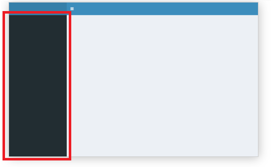

Construiremos passo a passo até chegarmos nesse objetivo final

- https://kaiquefhds.shinyapps.io/sidebar/

[figure not shown]

Utilize o Código Completo Sidebar e retire todo o Sidebar para construirmos gradativamente, primeiro vamos adicionar as informações do usuário

Usaremos a função *sidebarUserPanel*, onde sua documentação pode ser encontrada em [LINK](https://www.rdocumentation.org/packages/shinydashboard/versions/0.7.1/topics/sidebarUserPanel)

```r
Sidebar = dashboardSidebar(

    # Informações de usuários
    sidebarUserPanel(name = "Kaíque Ferreira",
                     subtitle = a(href = "#", icon("circle", class = "text-success"), # Círculo verde ao lado de "Online"
                                  "Autor"), # Texto ao lado do círculo
                     image = "https://uploaddeimagens.com.br/images/002/514/151/full/Kaique.PNG?1574687940") # Imagem do usuário
) # Fim da função dashboardSidebar
```

Com a função *sidebarMenu*, podemos adicionar as abas no Sidebar, documentação da função [LINK](https://www.rdocumentation.org/packages/shinydashboard/versions/0.7.1/topics/sidebarMenu)

[figure not shown]

```r
  # Abas do Sidebar
  sidebarMenu(

    menuItem("Gráfico Plotly", # Título visto pelo usuário
             icon = icon("th"), # Icone escolhido para a aba
             tabName = "plotly"), # ID da aba para posteriormente adicionar modificações

  ) # Fim da função sidebarMenu
```

Para as outras abas os argumentos funcionam da mesma forma

```r
  # Abas do Sidebar
  sidebarMenu(
    menuItem("Gráfico Plotly", # Título visto pelo usuário
             icon = icon("th"), # Icone escolhido para a aba
             tabName = "plotly"), # ID da aba para posteriormente adicionar modificações

    # Para as outras abas os argumentos funcionam da mesma forma

     menuItem("Gráfico Ggplot2",    icon = icon("dashboard"),   tabName = "ggplot2"),
     menuItem("Gráfico Highcharts", icon = icon("bar-chart-o"), tabName = "highcharts"),
     menuItem("Gráfico RBase",      icon = icon("bar-chart-o"), tabName = "rbase")

  ) # Fim da função sidebarMenu
```

E por fim, alcançamos nosso objetivo integrando mais essa parte ao nosso código

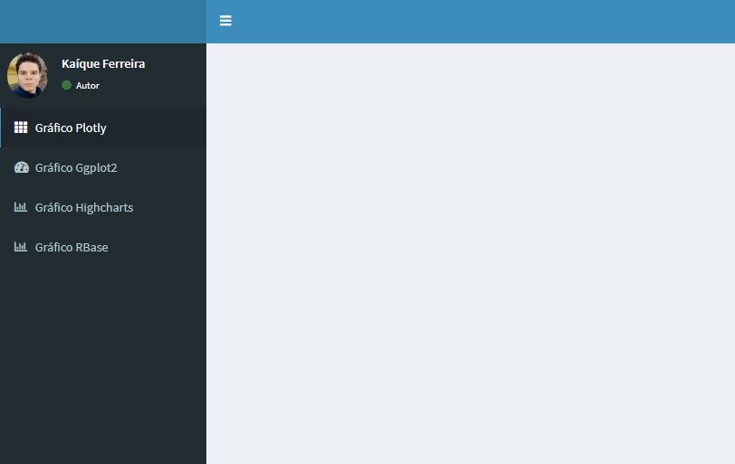

```r
Sidebar <- dashboardSidebar(

  # Informações de usuários
  sidebarUserPanel("Kaíque Ferreira",
                   subtitle = a(href = "#", icon("circle", class = "text-success"), # Círculo verde ao lado de "Online"
                                "Autor"), # Texto ao lado do círculo
                   image = "https://uploaddeimagens.com.br/images/002/514/151/full/Kaique.PNG?1574687940"),

  # Abas do Sidebar
  sidebarMenu(
    menuItem("Gráfico Plotly", # Título visto pelo usuário
             icon = icon("th"), # Icone escolhido para a aba
             tabName = "plotly"), # ID da aba para posteriormente adicionar modificações

    # Para as outras abas os argumentos funcionam da mesma forma

    menuItem("Gráfico Ggplot2",    icon = icon("dashboard"),   tabName = "ggplot2"),
    menuItem("Gráfico Highcharts", icon = icon("bar-chart-o"), tabName = "highcharts"),
    menuItem("Gráfico RBase",      icon = icon("bar-chart-o"), tabName = "rbase")

  ) # Fim da função sidebarMenu
) # Fim da função dashboardSidebar
```

.

### 2.4.3 Função: rightSidebar()

A função *rightSidebar* pertence ao pacote *shinydashboardPlus*, não esqueça desses três passos:

1. Instalar e carregar o pacote *shinydashboardPlus*
2. Trocar a função *dashboardHeader* por *dashboardHeaderPlus*
3. Trocar a função *dashboardPage* por *dashboardPagePlus*

A documentação da função *shinydashboardPlus* pode ser encontrada no [LINK](https://www.rdocumentation.org/packages/shinydashboardPlus/versions/0.7.0/topics/rightSidebar), as alterações dentro da função *rightSidebar* afetam a parte destacada na figura abaixo

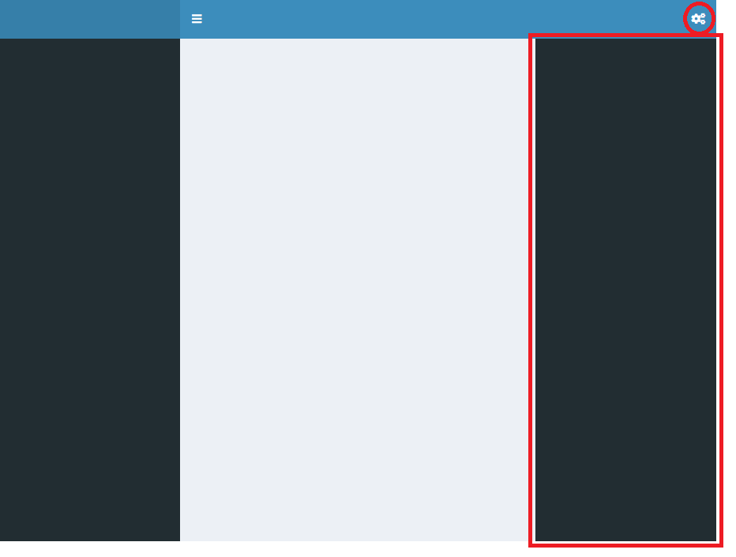

Construiremos passo a passo até chegarmos nesse objetivo final, lembre-se a parte de input e output serão configuradas posteriormente

- https://kaiquefhds.shinyapps.io/rightsidebar/

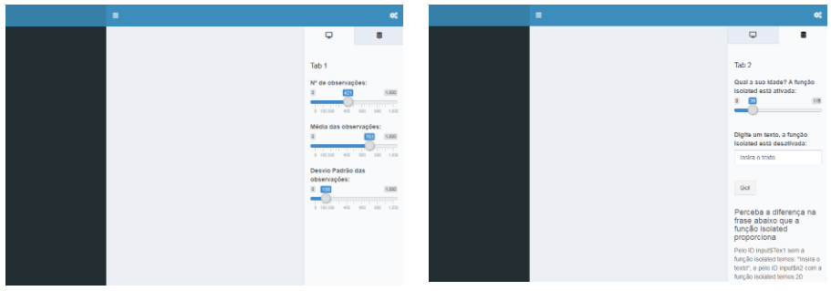

Para adicionar o *rightSidebar* precisamos dos seguintes argumentos dentro do *dashboardheaderPlus*

```r
Header = dashboardHeaderPlus(

  enable_rightsidebar = TRUE, # Ativando menu a direita
  rightSidebarIcon = "gears"  # Icone do menu a direita

) # Fim da função dashboardHeaderPlus
```

Agora sim já temos o *rightSidebar*, para fazer alterações precisamos alterar a função *dashboardPagePlus* da seguinte forma

```r
RightSidebar = rightSidebar()

UI = dashboardPagePlus(  Header, Sidebar,  Body , RightSidebar )
```

Todas as alterações ficam na função *rightSidebar* e para elas modificarem o Dashboard a função precisar ser incluida no *dashboardPagePlus*. Nossa primeira alteração no *rightSidebar* será colocando um tema com o seguinte argumento

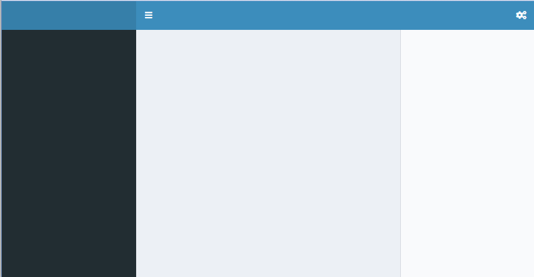

```r
RightSidebar = rightSidebar(

  background = "light", # Tema do rightSidebar, as opções são "dark" ou "light"

) # Fim da função rightSidebar
```

Para adicionar as abas usaremos a função *rightSidebarTabContent*, para mais detalhes sua documentação pode ser encontrado no [LINK](https://www.rdocumentation.org/packages/shinydashboardPlus/versions/0.7.0/topics/rightSidebarTabContent)

```r
  rightSidebarTabContent(  # Função para adicionar uma aba no rightSidebar
    id = 1,                # ID que define a ordem na qual vão aparecer as abas
    icon = "desktop",      # Icone da aba
    title = "Tab 1",       # Título da aba
    active = TRUE)         # Coloque esse argumento como TRUE na aba que deseja ser a primeira a ser exibida
```

Como nosso objetivo final tem duas abas basta colocar uma virgula após o ultimo parenteses de código acima e configurar a segunda aba e adicionar esse conjunto na função *rightSidebar* ficando da seguinte maneira

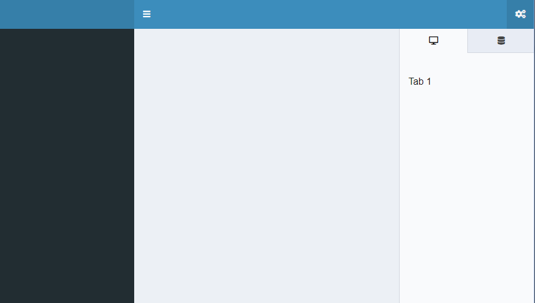

```r
RightSidebar = rightSidebar(
  background = "light", # Tema do rightSidebar, as opções são "dark" ou "light"

  rightSidebarTabContent( # Função para adicionar uma aba no rightSidebar
    id = 1,     # ID que define a ordem na qual vão aparecer as abas
    icon = "desktop", # Icone da aba
    title = "Tab 1",  # Título da aba
    active = TRUE), # Coloque esse argumento como TRUE na aba que deseja ser a primeira a ser exibida

  rightSidebarTabContent(  # Função para adicionar uma aba no rightSidebar
    id = 2,
    title = "Tab 2")

) # Fim da função rightSidebar
```

Na aba um adicionaremos o primeiro input em formato de barra de rolagem com o seguinte código abaixo

```r
    # Ferramentas de interação com o usuario
    sliderInput(inputId = "n1", label = "Nº de observações:",
      min = 0, max = 1000, value = 500)
```

Colocando uma vírgula após o ultimo argumento da função *rightSidebarTabContent* que gerou a primeira aba e adicioando o argumento acima teremos

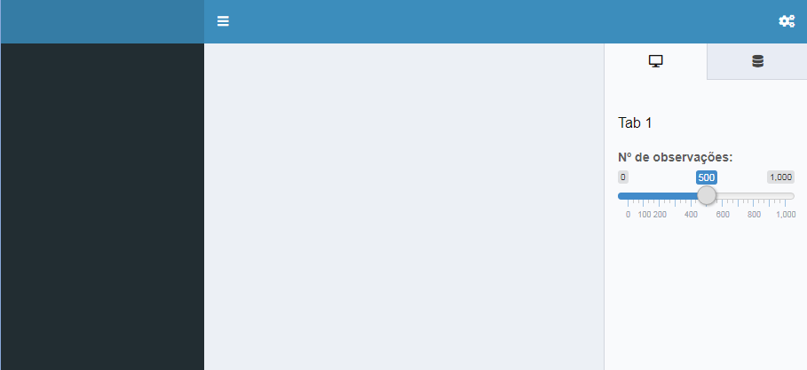

```r
RightSidebar = rightSidebar(
  background = "light", # Tema do rightSidebar, as opções são "dark" ou "light"

  rightSidebarTabContent( # Função para adicionar uma aba no rightSidebar
    id = 1,     # ID que define a ordem na qual vão aparecer as abas
    icon = "desktop", # Icone da aba
    title = "Tab 1",  # Título da aba
    active = TRUE, # Coloque esse argumento como TRUE na aba que deseja ser a primeira a ser exibida

    # Ferramentas de interação com o usuario
    sliderInput(inputId = "n1", label = "Nº de observações:",
                min = 0, max = 1000, value = 500)),

  rightSidebarTabContent(  # Função para adicionar uma aba no rightSidebar
    id = 2,
    title = "Tab 2")

) # Fim da função rightSidebar
```

Adicionaremos os outros dois inputs da mesma forma tendo o seguinte resultado

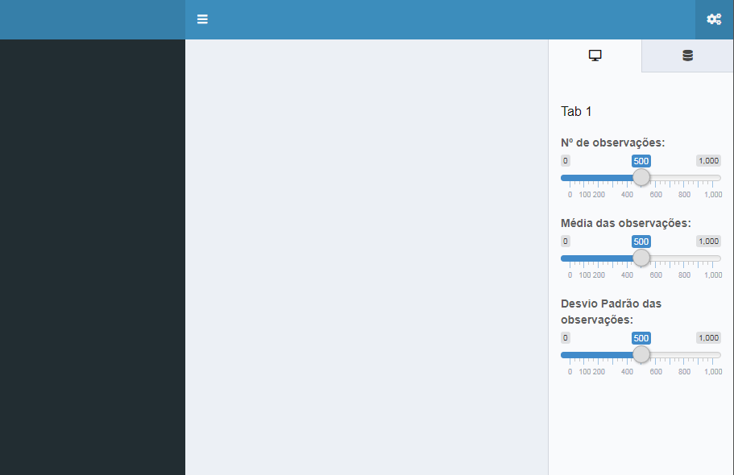

```r
RightSidebar = rightSidebar(
  background = "light", # Tema do rightSidebar, as opções são "dark" ou "light"

  rightSidebarTabContent( # Função para adicionar uma aba no rightSidebar
    id = 1,     # ID que define a ordem na qual vão aparecer as abas
    icon = "desktop", # Icone da aba
    title = "Tab 1",  # Título da aba
    active = TRUE, # Coloque esse argumento como TRUE na aba que deseja ser a primeira a ser exibida

    # Ferramentas de interação com o usuario
    sliderInput(inputId = "n1", label = "Nº de observações:",
                min = 0, max = 1000, value = 500),

    sliderInput(inputId = "deviopadrao", label = "Média das observações:",
                min = 0, max = 1000, value = 500),

    sliderInput(inputId = "media", label = "Desvio Padrão das observações:",
                min = 0, max = 1000, value = 500)

  ), # Fim do rightSidebarTabContent id 1

  rightSidebarTabContent(  # Função para adicionar uma aba no rightSidebar
    id = 2,
    title = "Tab 2")

) # Fim da função rightSidebar
```

Na segunda aba adicionaremos primeiro um input de dados no formato de barra de rolagem deixando o código da seguinte maneira

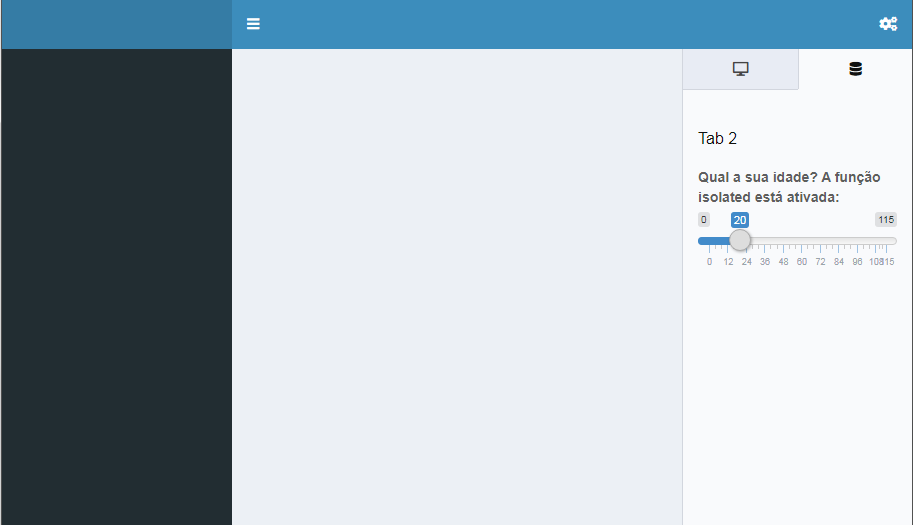

```r
RightSidebar = rightSidebar(
  background = "light", # Tema do rightSidebar, as opções são "dark" ou "light"

  rightSidebarTabContent( # Função para adicionar uma aba no rightSidebar
    id = 1,     # ID que define a ordem na qual vão aparecer as abas
    icon = "desktop", # Icone da aba
    title = "Tab 1",  # Título da aba
    active = TRUE, # Coloque esse argumento como TRUE na aba que deseja ser a primeira a ser exibida

    # Ferramentas de interação com o usuario
    sliderInput(inputId = "n1", label = "Nº de observações:",
                min = 0, max = 1000, value = 500),

    sliderInput(inputId = "deviopadrao", label = "Média das observações:",
                min = 0, max = 1000, value = 500),

    sliderInput(inputId = "media", label = "Desvio Padrão das observações:",
                min = 0, max = 1000, value = 500)

  ), # Fim do rightSidebarTabContent id 1

  rightSidebarTabContent(  # Função para adicionar uma aba no rightSidebar
    id = 2,
    title = "Tab 2",

    sliderInput("n2", "Qual a sua idade? A função isolated está ativada:",
                min = 0, max = 115, value = 20, step = 1))

) # Fim da função rightSidebar
```

O segundo input de dados é no formato texto ultilizando a seguinte função

```r
textInput("Tex1",     # Id do input
          "Digite um texto, a função isolated está desativada:",  # Nome do input
          "Insira o texto")   # Palavra inicial do input
```

Com o código acima sendo adicionado dentro da função *rightSidebarTabContent* de id=2 depois do input anterior que adicionamos teremos o seguinte resultado

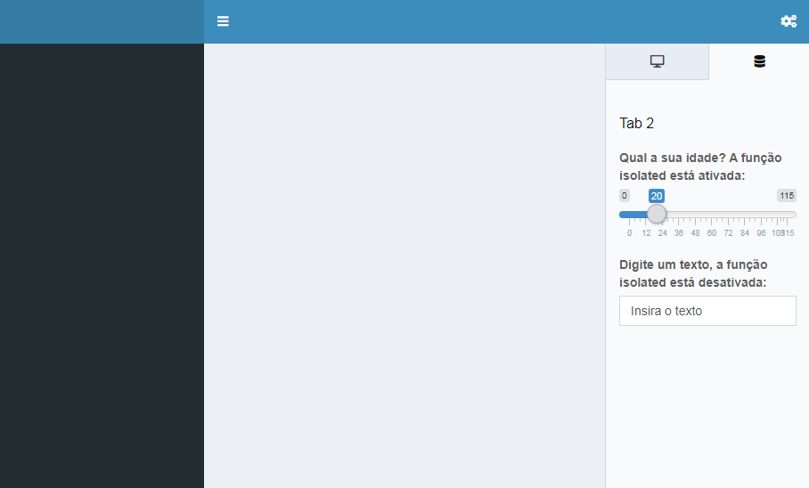

```r
RightSidebar = rightSidebar(
  background = "light", # Tema do rightSidebar, as opções são "dark" ou "light"

  rightSidebarTabContent( # Função para adicionar uma aba no rightSidebar
    id = 1,     # ID que define a ordem na qual vão aparecer as abas
    icon = "desktop", # Icone da aba
    title = "Tab 1",  # Título da aba
    active = TRUE, # Coloque esse argumento como TRUE na aba que deseja ser a primeira a ser exibida

    # Ferramentas de interação com o usuario
    sliderInput(inputId = "n1", label = "Nº de observações:",
                min = 0, max = 1000, value = 500),

    sliderInput(inputId = "deviopadrao", label = "Média das observações:",
                min = 0, max = 1000, value = 500),

    sliderInput(inputId = "media", label = "Desvio Padrão das observações:",
                min = 0, max = 1000, value = 500)

  ), # Fim do rightSidebarTabContent id 1

  rightSidebarTabContent(  # Função para adicionar uma aba no rightSidebar
    id = 2,
    title = "Tab 2",

    sliderInput("n2", "Qual a sua idade? A função isolated está ativada:",
                min = 0, max = 115, value = 20, step = 1),

     textInput("Tex1",     # Id do input
          "Digite um texto, a função isolated está desativada:",  # Nome do input
          "Insira o texto")   # Palavra inicial do input

   ) # Fim do rightSidebarTabContent id 2
) # Fim da função rightSidebar
```

Adicionaremos agora um botão de ação com o nome de *Go!*, para isso usaremos a função

```r
actionButton("ButaoGO", # Id do botão de ação
             "Go!"      # Nome do botão de ação
) # Fim do butão de ação
```

Mas antes do botão de ação adicionaremos a função *br* para deixar um espaço entre o botão de ação e o input anterior, obteremos o seguinte resultado

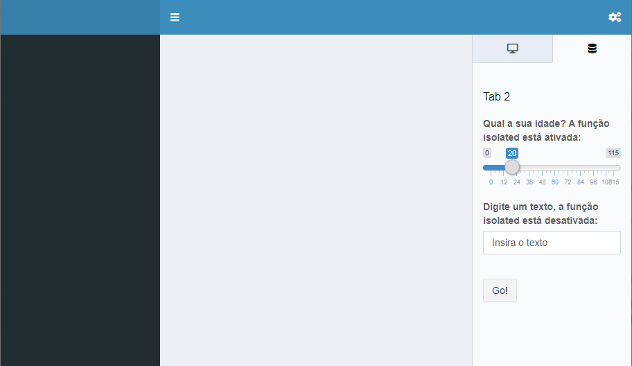

```r
RightSidebar = rightSidebar(
  background = "light", # Tema do rightSidebar, as opções são "dark" ou "light"

  rightSidebarTabContent( # Função para adicionar uma aba no rightSidebar
    id = 1,     # ID que define a ordem na qual vão aparecer as abas
    icon = "desktop", # Icone da aba
    title = "Tab 1",  # Título da aba
    active = TRUE, # Coloque esse argumento como TRUE na aba que deseja ser a primeira a ser exibida

    # Ferramentas de interação com o usuario
    sliderInput(inputId = "n1", label = "Nº de observações:",
                min = 0, max = 1000, value = 500),

    sliderInput(inputId = "deviopadrao", label = "Média das observações:",
                min = 0, max = 1000, value = 500),

    sliderInput(inputId = "media", label = "Desvio Padrão das observações:",
                min = 0, max = 1000, value = 500)

  ), # Fim do rightSidebarTabContent id 1

  rightSidebarTabContent(  # Função para adicionar uma aba no rightSidebar
    id = 2,
    title = "Tab 2",

    sliderInput("n2", "Qual a sua idade? A função isolated está ativada:",
                min = 0, max = 115, value = 20, step = 1),

     textInput("Tex1", "Digite um texto, a função isolated está desativada:", "Insira o texto"),

    br(), # Adiciona um espaço na vertical

    actionButton("ButaoGO", "Go!") # butão de ação

   ) # Fim do rightSidebarTabContent id 2
) # Fim da função rightSidebar
```

Por fim adicionaremos um texto e que na parte de server vamos aprender a tornar ele interatico, para adicionar o texto usaremos a função h4 e h5 da seguinte forma

```r
    h4("Perceba a diferença na frase abaixo que a função isolated proporciona"),
    # h1, h2, h3, h4,... são código de htlm para tamanho de letra

    h5('Pelo ID input$Tex1 sem a função isolated temos: Insira o texto,
       e pelo ID input$n2 com a função isolated temos 20')
    # Está desabilitada, na parte de Server ensino a usar
```

Antes dessas duas funções de texto iremos adicionar duas funções *br*, da seguinte forma

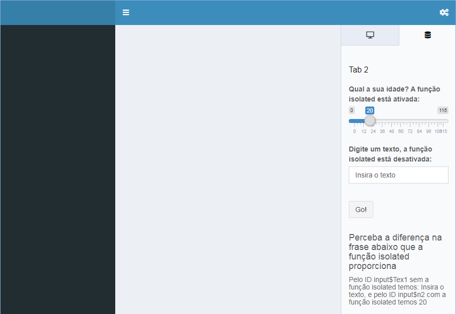

```r
RightSidebar = rightSidebar(
  background = "light", # Tema do rightSidebar, as opções são "dark" ou "light"

  rightSidebarTabContent( # Função para adicionar uma aba no rightSidebar
    id = 1,     # ID que define a ordem na qual vão aparecer as abas
    icon = "desktop", # Icone da aba
    title = "Tab 1",  # Título da aba
    active = TRUE, # Coloque esse argumento como TRUE na aba que deseja ser a primeira a ser exibida

    # Ferramentas de interação com o usuario
    sliderInput(inputId = "n1", label = "Nº de observações:",
                min = 0, max = 1000, value = 500),

    sliderInput(inputId = "deviopadrao", label = "Média das observações:",
                min = 0, max = 1000, value = 500),

    sliderInput(inputId = "media", label = "Desvio Padrão das observações:",
                min = 0, max = 1000, value = 500)

  ), # Fim do rightSidebarTabContent id 1

  rightSidebarTabContent(  # Função para adicionar uma aba no rightSidebar
    id = 2,
    title = "Tab 2",

    sliderInput("n2", "Qual a sua idade? A função isolated está ativada:",
                min = 0, max = 115, value = 20, step = 1),

     textInput("Tex1", "Digite um texto, a função isolated está desativada:", "Insira o texto"),

    br(), # Adiciona um espaço na vertical

    actionButton("ButaoGO", "Go!"), # butão de ação

    br(),
    br(),

    h4("Perceba a diferença na frase abaixo que a função isolated proporciona"),
    # h1, h2, h3, h4,... são código de htlm para tamanho de letra

    h5('Pelo ID input$Tex1 sem a função isolated temos: Insira o texto,
       e pelo ID input$n2 com a função isolated temos 20')
    # Está desabilitada, na parte de Server ensino a usar

   ) # Fim do rightSidebarTabContent id 2
) # Fim da função rightSidebar
```

.